# 统计计算 Homework 5

林子开 21307110161

2023年11月

# Exercise 6.1

First, define a function which calculates the k-th trimmed means for random samples x.

```r
trimed.means <- function(x,k){
  x <- sort(x)
  return( sum(x[(k+1):(n-k)])/(n-2*k) )
}
```

Here comes the experiment. Repeat the calculation for m times and get an estimate of MSE for different k’s.

```r
m <- 100 # replicating times
n <- 20 # sample size
set.seed(123)
smp <- matrix(rcauchy(n*m),nrow=n)
mse <- numeric(9)
for(k in 1:9){
  tmeans <- numeric(m)
  for(j in 1:m){
    tmeans[j] <-trimed.means(smp[,j],k)
  }
  mse[k] = mean((tmeans-mean(tmeans))^2)
}
```

Now summarize the estimates of MSE in a table. Moreover, give a plot.

```r
k = 1:9
rbind(k,mse)
```

```
##          [,1]      [,2]      [,3]      [,4]      [,5]      [,6]     [,7]
## k   1.0000000 2.0000000 3.0000000 4.0000000 5.0000000 6.0000000 7.000000
## mse 0.6705808 0.3641673 0.2549835 0.2071425 0.1751477 0.1533487 0.143097
##         [,8]      [,9]
## k   8.000000 9.0000000
## mse 0.134522 0.1380392
```

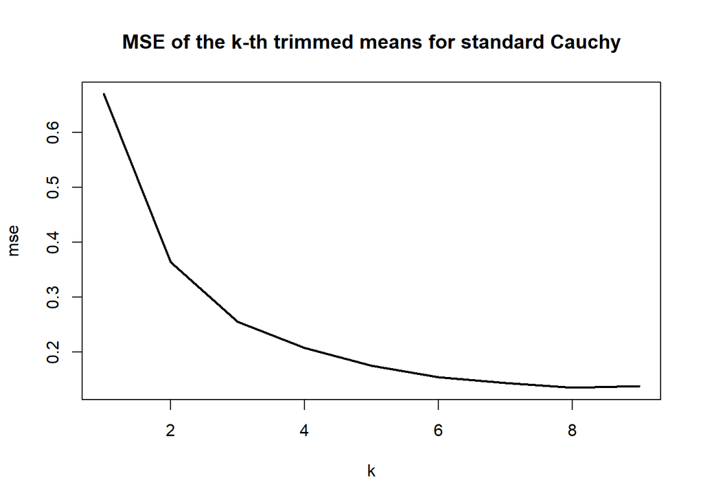

```r
plot(k,mse,type='l',lwd=2,main='MSE of the k-th trimmed means for standard Cauchy')
```

# Exercise 6.4

First, generate the samples with $\mu=1$.

```r
m <- 10000 # constructing the CI for m times
n <- 1000 # sample size
set.seed(233)
miu.true = 1
smp = matrix(rlnorm(n*m,meanlog = miu.true),nrow = n)
```

Since $\mu=\mathbb{E}[\log(X)]$, we need to transfer $X$ to $\log(X)$ and then calculate $\overline{\log(X)}$ as well as $\hat{se}(\overline{\log(X)})$

```r
smp.log = log(smp)
miu = apply(smp.log,2,mean) # average
sd = apply(smp.log,2,sd) # estimate of standard deviation
se = sd/sqrt(n) # estimate of standard error
```

Notice that $\log(X)\sim \mathcal{N}(\mu,\sigma^2)$ and $\overline{\log(X)} \sim \mathcal{N}(\mu,\frac{\sigma^2}{n})$, we can construct the CI as follows:

```r
z = qnorm(0.975)
# construct an 95% CI for mu
CI.low = miu - z*se
CI.high = miu + z*se
CI = cbind(CI.low,CI.high)
```

Finally, use Monte Carlo method to obtain an empirical estimate of the confidence level and verify my construction of the 95% CI for parameter $\mu$.

```r
# find the empirical confidence level
confidence_level <- sum(CI.low<miu.true & miu.true<CI.high)/m
print(confidence_level) # 0.9515
```

```
## [1] 0.9515
```

# Exercise 6.5

First, generate the random samples from $\chi^2(2)$ and give a symmetric t-interval to estimate the mean.

```r
m = 10000 # repeating times
n = 20 # sample size
set.seed(233)
smp = matrix(rchisq(n*m,df=2),nrow = n) # generate samples
means = apply(smp,2,mean) # calculate the average
sd = apply(smp,2,sd) # the estimate of standard deviation
se = sd/sqrt(n) # the estimate of standard error
z = qt(0.975,df=n-1) # quantile of t distribution with degree of freedom n-1
CI.low = means - z*se
CI.high =  means + z*se
CI = cbind(CI.low,CI.high)
```

Now estimate the coverage probability using Monte Carlo method. Notice that if $X\sim \chi^2(x)$, then $\mathbb{E}[X]=2$.

```r
coverage_prob = sum(CI.low<2 & 2<CI.high)/m
print(coverage_prob) # 0.9161
```

```
## [1] 0.9161
```

Notice that in Example 6.4 and Example 6.6, where we calculate the CI for variance with samples from $\chi^2(2)$. We only got an estimate of 77.3% for the coverage probability of variance, far away from 95% coverage under normality. But here we’ve got an estimate of 91.61% for the coverage probability of mean, which is much closer to 95% under normality. Therefore we can conclude that the t-interval is more **robust** to departures from normality than the interval for variance.

# Exercise 6.9

First, define a function which calculates an estimate for Gini ratio of sample X.

```r
G <- function(x.raw){ # 计算基尼系数
  x = sort(x.raw) # turn x.raw into ordering statistics
  n = length(x)
  miu = mean(x)
  G = (1/(n^2*miu)) * sum((2*(1:n)-n-1)*x)
  return(G)
}
```

## Gini ratio for lognormal distribution

First, generate samples from standard lognormal and calculate the estimate of Gini ratios.

```r
m = 1000 # repeating times
n = 1000 # sample size
set.seed(233)
smp = matrix(rlnorm(m*n),nrow=n)
G.lognormal = apply(smp,2,G) # calculate Gini ratio
```

The mean and median are

```r
G.lognormal.mean = mean(G.lognormal)
G.lognormal.median = median(G.lognormal)
rbind(c('mean','median'),c(G.lognormal.mean,G.lognormal.median))
```

```
##      [,1]                [,2]
## [1,] "mean"              "median"
## [2,] "0.519732073166323" "0.519239673258696"
```

The deciles are

```r
G.lognormal.deciles = quantile(G.lognormal, probs = seq(.1, .9, by = .1))
print(G.lognormal.deciles)
```

```
##       10%       20%       30%       40%       50%       60%       70%       80%
## 0.5030349 0.5083522 0.5122230 0.5156421 0.5192397 0.5224640 0.5264712 0.5308015
##       90%
## 0.5381967
```

And the histograms of the Gini ratio estimates are

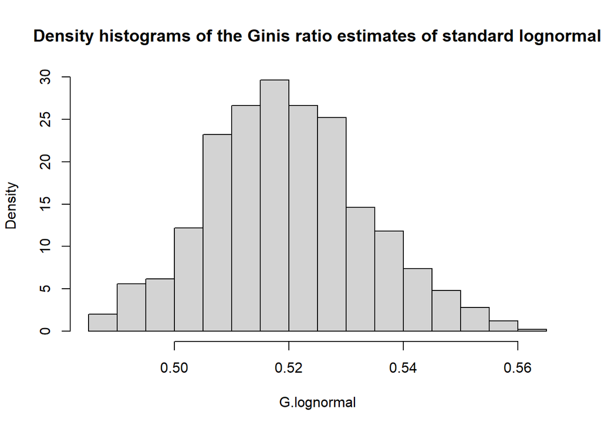

```r
hist(G.lognormal, freq = F, main = "Density histograms of the Ginis ratio estimates of standard lognormal") # Create a histogram
```

## Gini ratio for uniform distribution

First, generate samples from uniform distribution and calculate the estimate of Gini ratios.

```r
set.seed(233)
smp = matrix(runif(m*n),nrow=n)
G.uniform = apply(smp,2,G)
```

The mean and median are

```r
G.uniform.mean = mean(G.uniform)
G.uniform.median = median(G.uniform)
rbind(c('mean','median'),c(G.uniform.mean,G.uniform.median))
```

```
##      [,1]                [,2]
## [1,] "mean"              "median"
## [2,] "0.333360038607124" "0.333104429365867"
```

The deciles are

```r
G.uniform.deciles = quantile(G.uniform, probs = seq(.1, .9, by = .1))
print(G.uniform.deciles)
```

```
##       10%       20%       30%       40%       50%       60%       70%       80%
## 0.3233482 0.3267294 0.3290776 0.3312661 0.3331044 0.3351638 0.3376852 0.3400776
##       90%
## 0.3434901
```

And the histograms of the Gini ratio estimates is

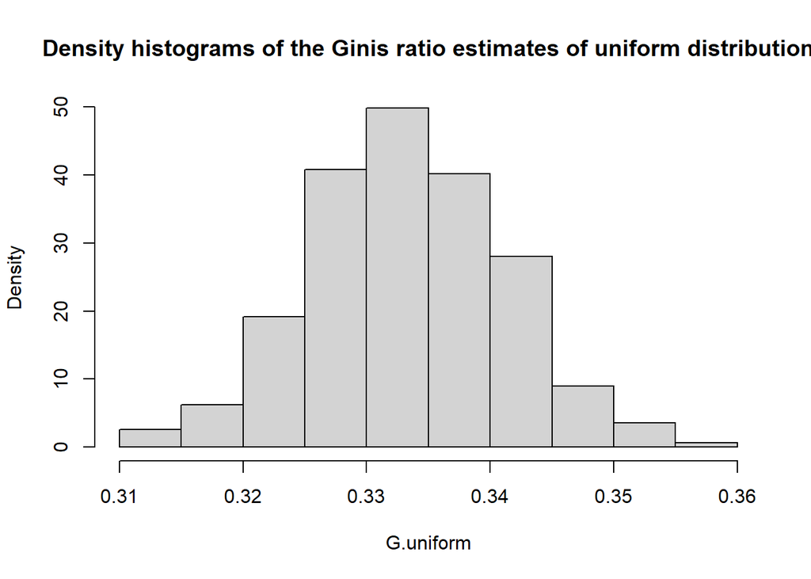

```r
hist(G.uniform, freq = FALSE, main = "Density histograms of the Ginis ratio estimates of uniform distribution") # Create a histogram
```

## Gini ratio for Bernoulli distribution

First, generate samples from Bernoulli(0.1) and calculate the estimates of Gini ratios.

```r
set.seed(233)
smp = matrix(rbinom(m*n,size=1,prob=0.1),nrow=n)
G.Bernoulli = apply(smp,2,G)
```

The mean and median are

```r
G.Bernoulli.mean = mean(G.Bernoulli)
G.Bernoulli.median = median(G.Bernoulli)
rbind(c('mean','median'),c(G.Bernoulli.mean,G.Bernoulli.median))
```

```
##      [,1]       [,2]
## [1,] "mean"     "median"
## [2,] "0.899949" "0.9"
```

The deciles are

```r
G.Bernoulli.deciles = quantile(G.Bernoulli, probs = seq(.1, .9, by = .1))
print(G.Bernoulli.deciles)
```

```
##   10%   20%   30%   40%   50%   60%   70%   80%   90%
## 0.888 0.892 0.895 0.898 0.900 0.902 0.905 0.908 0.911
```

And the histograms of the estimates for Gini ratios is

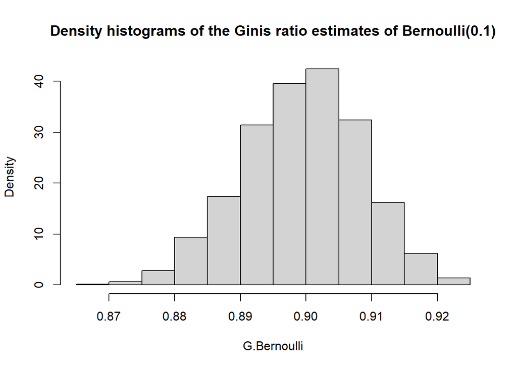

```r
hist(G.Bernoulli, freq = FALSE, main = "Density histograms of the Ginis ratio estimates of Bernoulli(0.1)") # Create a histogram
```

# Exercise 6.10

According to [Wikipedia](https://en.wikipedia.org/wiki/Gini_coefficient#cite_ref-LNdist_29-1), the Gini ratio $\gamma=\mathbb{E}[G]$ of lognormal distribution is $2\Phi\left(\frac{\sigma}{\sqrt{2}}\right)-1$. Since the parameter $\sigma$ is unknown, we need to construct CI’s for $\sigma$ before constructing that for $G$.

We generate samples from lognormal and construct CI’s for $\sigma$ as follows:

```r
sigma.true = 5 # the real sigma
G.true = 2*pnorm(sigma.true/sqrt(2)) - 1
set.seed(233)
# sampling
smp = matrix(rlnorm(m*n,meanlog=0,sdlog=sigma.true),nrow=n)
smp.log = log(smp)
# calculate the sample variance for each column
S2 = apply(smp.log,2,var) # sample variance
# construct a 95% CI for sigma
sigma.CI.low = numeric(m)
sigma.CI.high = sqrt((n-1)*S2/qchisq(.05,df=n-1))
sigma.CI = cbind(sigma.CI.low,sigma.CI.high)
```

Based on the relation between $\sigma$ and $G$, we can construct an approximately 95% CI for Gini ratio:

```r
# construct a 95% CI for G.true
G.CI.low = numeric(m)
G.CI.high = 2*pnorm(sigma.CI.high/sqrt(2))-1
G.CI = cbind(G.CI.low,G.CI.high)
```

Using Monte Carlo method to estimate the empirical coverage rate:

```r
confidence_level = sum(G.CI.low<G.true & G.true<G.CI.high)/m
print(confidence_level) #  0.951
```

```
## [1] 0.951
```

# Proof

First I shall introduce some notation. Let $X=(x_1,x_2,\cdots,x_n)^\top$ and $\vec{\mu}=(\mu,\mu,\cdots,\mu)^\top,\,\vec{\mu}\in\mathbb{R}^n$. Since $x_i\sim N(\mu,\sigma^2)$ and $x_i$ are i.i.d., then we have: $X \sim N(\vec{\mu},\sigma^2 I)$.

First, make a transformation:
$$\begin{align*}
&\sum_{i=1}^{n}(x_i-\bar{x})^2/\sigma^2 \\
& = \frac{\left(\sum_{i=1}^{n}x_i^2-n\bar{x}^2\right)}{\sigma^2} \\
& =
\sum_{i=1}^{n}\left(\frac{x_i}{\sigma}\right)^2-n\left(\frac{\bar{x}}{\sigma}\right)^2
\end{align*}$$

Now let $Y = \frac{X}{\sigma}$, then we have $y_i \sim N(\frac{\mu}{\sigma},1)$, and moreover
$$Y \sim N\left(\frac{\vec{\mu}}{\sigma},I\right)$$

Therefore
$$\begin{align*}
& \sum_{i=1}^{n}\left(\frac{x_i}{\sigma}\right)^2-n\left(\frac{\bar{x}}{\sigma}\right)^2
\\
& =\sum_{i=1}^{n}y_i^2 - n(\bar{y})^2\\
\end{align*}$$

Here comes the most tricky part. We should design an **orthogonal** matrix $Q$ as
$$Q = \begin{bmatrix}
\quad q_1^\top \quad\\
\quad q_2^\top \quad\\
\quad\vdots\quad \\
\quad q_n^\top \quad
\end{bmatrix}$$
where
$$q_n^\top =
\left[\frac{1}{\sqrt{n}},\frac{1}{\sqrt{n}},\cdots,\frac{1}{\sqrt{n}}
\right]$$

Now make a transformation
$$z_i=q_i^\top Y = \sum_{j=1}^{n}q_{ij}y_i$$
for simplicity, we can alternatively write $Z=QY$. Notice that
$$z_n = \frac{y_1+y_2+\cdots+y_n}{\sqrt{n}} = \sqrt{n}\bar{y}$$

Since $Q$ is **orthogonal**, i.e., $Q^\top Q=I$, then we can derive the distribution of Z
$$Z \sim N\left(\frac{Q\vec{\mu}}{\sigma},I\right)$$

Since the 2-norm is unchanged under orthogonal transformation, we also have
$$\begin{align*}
&||Z||_2 = ||QY||_2 = ||Y||_2 \\
\Rightarrow &\sum_i z_i^2 = \sum_i y_i^2
\end{align*}$$

Therefore
$$\begin{align*}
& \sum_{i=1}^{n}y_i^2 - n(\bar{y})^2\\
& =\sum_{i=1}^{n}z_i^2 - z_n^2 \\
& =\sum_{i=1}^{n-1}z_i^2
\end{align*}$$

When $i\ne n$, we can prove that $\mathbb{E}[z_i]=0$
$$\begin{align*}
\mathbb{E}[z_i] &= \mathbb{E}[q_i^\top Y] \\
&= \mathbb{E}\left[\sum_{j=1}^{n}q_{ij}y_i\right] \\
&= \sum_{j=1}^{n}q_{ij}\mathbb{E}[y_i] \\
&= \sum_{j=1}^{n}q_{ij}\frac{\mu}{\sigma} \\
&= \sum_{j=1}^{n}q_{ij}\frac{1}{\sqrt{n}}\sqrt{n}\frac{\mu}{\sigma}
\\
&=0
\end{align*}$$
The last equation holds because $q_i^\top q_n =0,\, i\ne n$. Now we have proven that
$$z_i \sim N(0,1),\,i\ne
n$$
Since $\sum_{i=1}^{n}(x_i-\bar{x})^2/\sigma^2 = \sum_{i=1}^{n-1}z_i^2$, according to the definition of Chi-square distribution, we can conclude that
$$\sum_{i=1}^{n}(x_i-\bar{x})^2/\sigma^2 \sim \chi^2(n-1)$$

Notice that $\bar{x} = \sigma\bar{y}=\frac{\sigma z_n}{\sqrt{n}}$, i.e., $\bar{x}$ is only determined by $z_n$, whereas $\sum_{i=1}^{n}(x_i-\bar{x})^2/\sigma^2$ is only determined by $z_1,z_2,\cdots,z_{n-1}$. Since $Z \sim N\left(\frac{Q\vec{\mu}}{\sigma},I\right)$, $\rho_{ij}=0,\, i\ne j$, i.e., $z_i$ and $z_j$ are independent if $i\ne j$, we draw the conclusion that $\sum_{i=1}^{n}(x_i-\bar{x})^2/\sigma^2$ is independent with $\bar{x}$.

$\blacksquare$